# Topic 1 Parametric Inference

Shubhangi Mistari

2024-12-31

#Topic 1

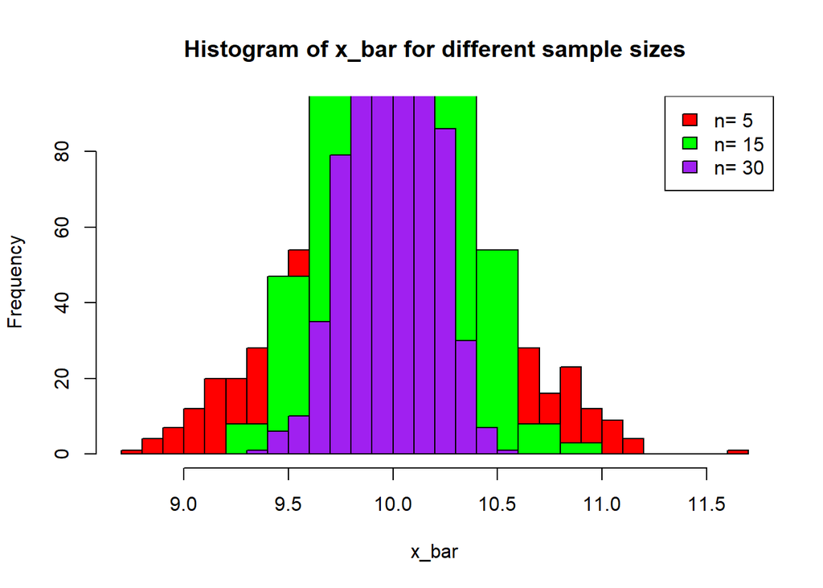

```r
n=c(5,15,30)
sam_mean=sam_var=numeric(length(n))
x_bar_list=list()
for (i in 1:length(n)){
  x=matrix(rnorm(1000*n[i],10,1),nrow = 1000,ncol = n[i])
  x_bar=apply(x,1,mean)
  sam_mean[i]=mean(x_bar)
  sam_var[i]=var(x_bar)
  x_bar_list[[i]]=x_bar

}

hist(x_bar_list[[1]],breaks="FD",col="red",main="Histogram of x_bar for different sample sizes",xlab="x_bar")
hist(x_bar_list[[2]],col="green",add=T)
hist(x_bar_list[[3]],col="purple",add=T)
legend("topright",legend=paste("n=",n),
       fill=c("red","green","purple"))
```

```r
cbind(n,sam_mean,sam_var)
```

```
##       n  sam_mean    sam_var
## [1,]  5  9.993356 0.20428527
## [2,] 15 10.013874 0.06703486
## [3,] 30  9.994259 0.03205366
```

From this output, we conclude that as sample size increases,variability in the sample mean is decreases. Also, sample mean tends to population mean as n increases.

##2.Sample median

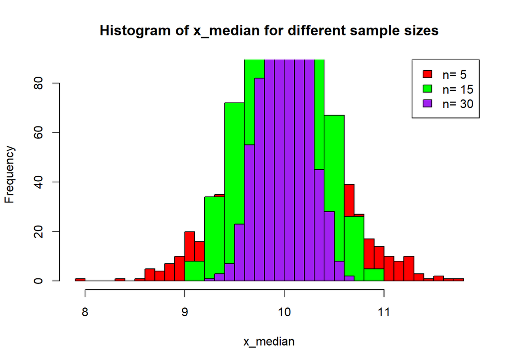

```r
n=c(5,15,30)
sam_median_mean=sam_median_var=numeric(length(n))
x_median_list=list()
for (i in 1:length(n)){
  x=matrix(rnorm(1000*n[i],10,1),nrow = 1000,ncol = n[i])
  x_median=apply(x,1,median)
  sam_median_mean[i]=mean(x_median)
  sam_median_var[i]=var(x_median)
  x_median_list[[i]]=x_median
}
hist(x_median_list[[1]],breaks="FD",col="red",main="Histogram of x_median for different sample sizes",xlab="x_median")
hist(x_median_list[[2]],col="green",add=T)
hist(x_median_list[[3]],col="purple",add=T)
legend("topright",legend=paste("n=",n),
       fill=c("red","green","purple"))
```

```r
cbind(n,sam_median_mean,sam_median_var)
```

```
##       n sam_median_mean sam_median_var
## [1,]  5       10.003149     0.28474581
## [2,] 15        9.984159     0.10647027
## [3,] 30        9.998181     0.04844444
```

From this output, we conclude that as sample size increases,variability in the sample median is decreases.

##3.Sample variance

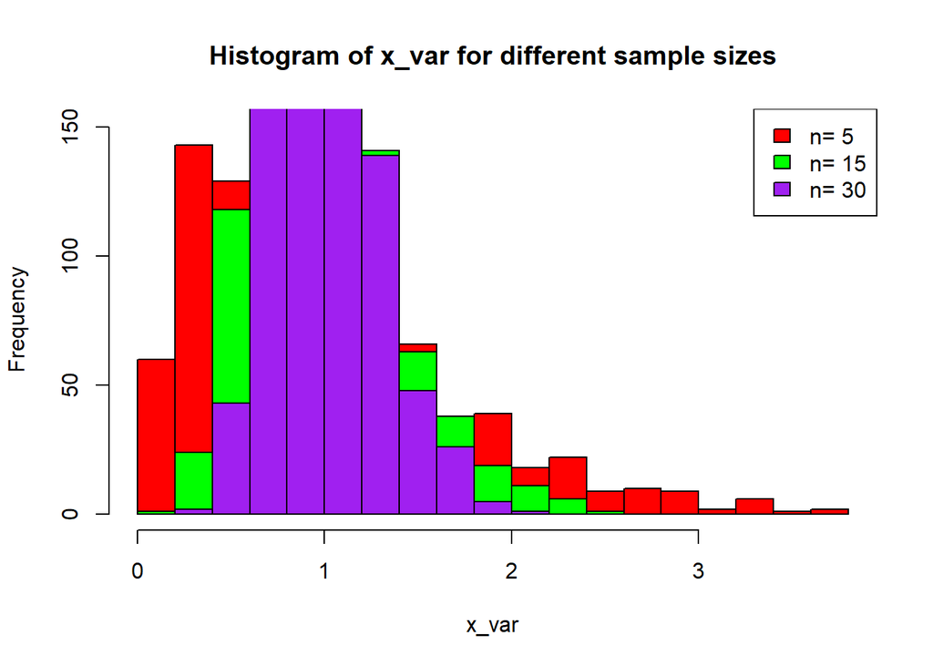

```r
n=c(5,15,30)
sam_var_mean=sam_var_var=numeric(length(n))
x_var_list=list()
for (i in 1:length(n)){
  x=matrix(rnorm(1000*n[i],10,1),nrow = 1000,ncol = n[i])
  x_var=apply(x,1,var)
  sam_var_mean[i]=mean(x_var)
  sam_var_var[i]=var(x_var)
  x_var_list[[i]]=x_var

}

hist(x_var_list[[1]],breaks="FD",col="red",main="Histogram of x_var for different sample sizes",xlab="x_var")
hist(x_var_list[[2]],col="green",add=T)
hist(x_var_list[[3]],col="purple",add=T)
legend("topright",legend=paste("n=",n),
       fill=c("red","green","purple"))
```

```r
cbind(n,sam_var_mean,sam_var_var)
```

```
##       n sam_var_mean sam_var_var
## [1,]  5    0.9675563  0.43249170
## [2,] 15    0.9959796  0.14825365
## [3,] 30    1.0061041  0.07419169
```

From this output, we conclude that as sample size increases,variability in the sample variance is decreases.

2.Example

To conduct the simulation study from Poisson($\lambda$=2.5) distribution. Demonstrate the distribution and it’s descriptive statistics for different sample sizes of following statistic/estimators.

## sample mean & sample variance

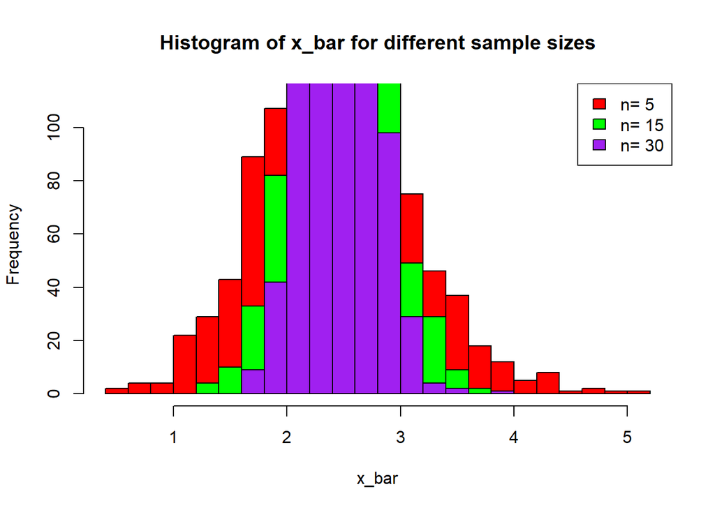

```r
n=c(5,15,30)
sam_mean=sam_var=numeric(length(n))
sam_var_mean=sam_var_var=numeric(length(n))
x_bar_list1=list()
x_var_list2=list()
for (i in 1:length(n)){
  x=matrix(rpois(1000*n[i],2.5),nrow = 1000,ncol = n[i])

  x_bar=apply(x,1,mean)
  x_var=apply(x,1,var)

  sam_mean[i]=mean(x_bar)
  sam_var_mean[i]=mean(x_var)


  sam_var[i]=var(x_bar)
  sam_var_var[i]=var(x_var)

  x_bar_list[[i]]=x_bar
  x_var_list[[i]]=x_var

}

hist(x_bar_list[[1]],breaks="FD",col="red",main="Histogram of x_bar for different sample sizes",xlab="x_bar")
hist(x_bar_list[[2]],col="green",add=T)
hist(x_bar_list[[3]],col="purple",add=T)
legend("topright",legend=paste("n=",n),
       fill=c("red","green","purple"))
```

```r
cbind(n,sam_mean,sam_var)
```

```
##       n sam_mean    sam_var
## [1,]  5 2.519000 0.49509409
## [2,] 15 2.494867 0.16387085
## [3,] 30 2.490300 0.08828419
```

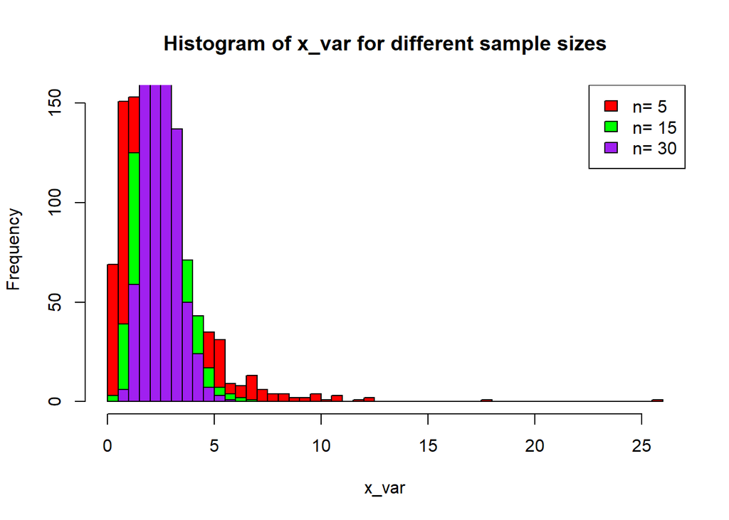

```r
hist(x_var_list[[1]],breaks="FD",col="red",main="Histogram of x_var for different sample sizes",xlab="x_var")
hist(x_var_list[[2]],col="green",add=T)
hist(x_var_list[[3]],col="purple",add=T)
legend("topright",legend=paste("n=",n),
       fill=c("red","green","purple"))
```

```r
cbind(n,sam_var_mean,sam_var_var)
```

```
##       n sam_var_mean sam_var_var
## [1,]  5     2.520800   4.2407681
## [2,] 15     2.419143   0.9769414
## [3,] 30     2.489769   0.5268510
```

From this output, we conclude that as sample size increases,variability in the sample mean and sample variance is decreases. Also, sample mean tends to population mean as n increases and sample variance tends to population variance as n increases.

3. Example To conduct the simulation study from U(0,$\theta$),$\theta$>0 distribution. Demonstrate the distribution and it’s descriptive statistics for different sample sizes of following statistic/estimators.

T1=2*($\bar{x}$) & T2=$x_{(n)}$

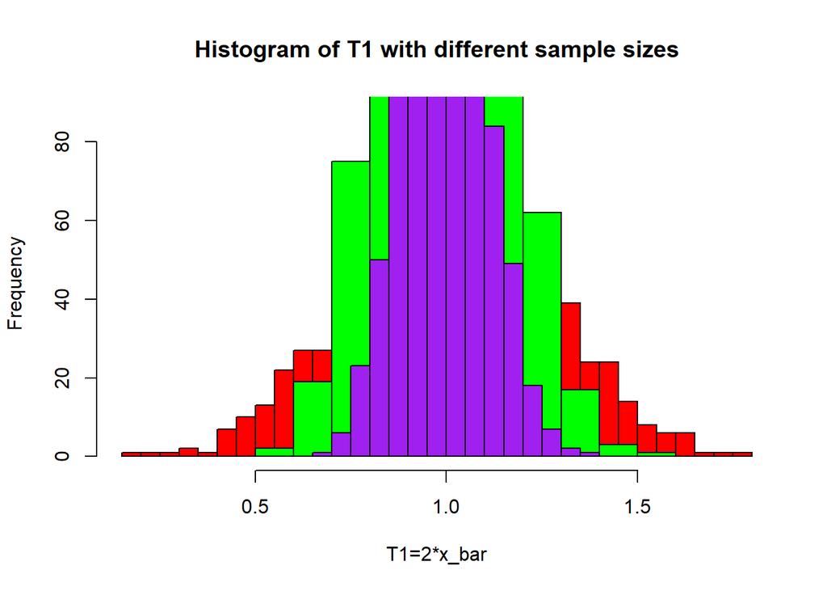

```r
n=c(5,15,30)
sam_mean_T1=sam_var_T1=numeric(length(n))
sam_mean_T2=sam_var_T2=numeric(length(n))

T1_list=list()
T2_list=list()

for (i in 1:length(n)){
  x=matrix(runif(1000*n[i],0,1),nrow = 1000,ncol = n[i])

  x_bar=apply(x,1,mean)
  T1=2*x_bar
  T2=apply(x,1,max)

  sam_mean_T1[i]=mean(T1)
  sam_mean_T2[i]=mean(T2)

  sam_var_T1[i]=var(T1)
  sam_var_T2[i]=var(T2)

  T1_list[[i]]=T1
  T2_list[[i]]=T2

}

hist(T1_list[[1]],breaks="FD",col="red",main="Histogram of T1 with different sample sizes",xlab="T1=2*x_bar")
hist(T1_list[[2]],col="green",add=T)
hist(T1_list[[3]],col="purple",add=T)
```

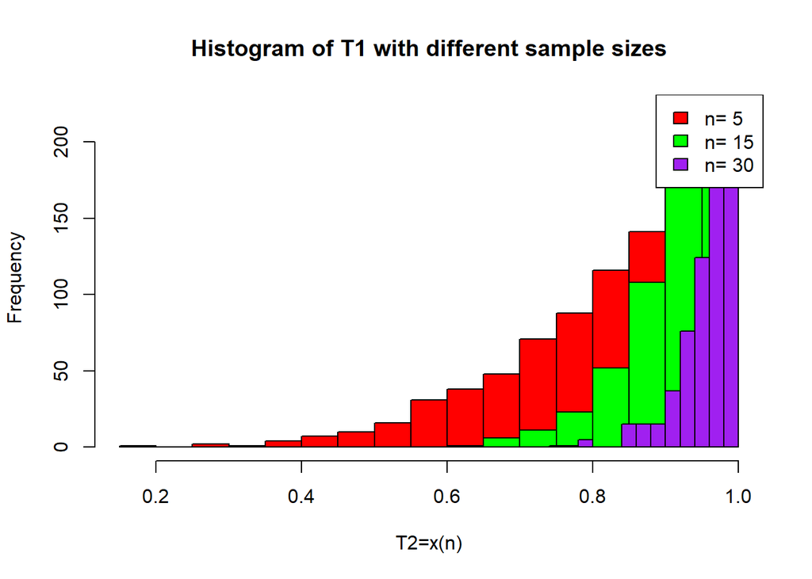

```r
hist(T2_list[[1]],breaks="FD",col="red",main="Histogram of T1 with different sample sizes",xlab="T2=x(n)")
hist(T2_list[[2]],col="green",add=T)
hist(T2_list[[3]],col="purple",add=T)

legend("topright",legend=paste("n=",n),
       fill=c("red","green","purple"))
```

```r
cbind(n,sam_mean_T1,sam_var_T1)
```

```
##       n sam_mean_T1 sam_var_T1
## [1,]  5   1.0047484 0.06276643
## [2,] 15   0.9977448 0.02227087
## [3,] 30   0.9994049 0.01100652
```

```r
cbind(n,sam_mean_T2,sam_var_T2)
```

```
##       n sam_mean_T2  sam_var_T2
## [1,]  5   0.8376534 0.018872449
## [2,] 15   0.9367678 0.003701468
## [3,] 30   0.9663665 0.001199930
```

From this output, we conclude that as sample size increases variability in T1 and T2 decreases.

4. Example To conduct the simulation study from Exponential distribution with location parameter $\mu$. Demonstrate the distribution and it’s descriptive statistics for different sample sizes of following statistic/estimators.

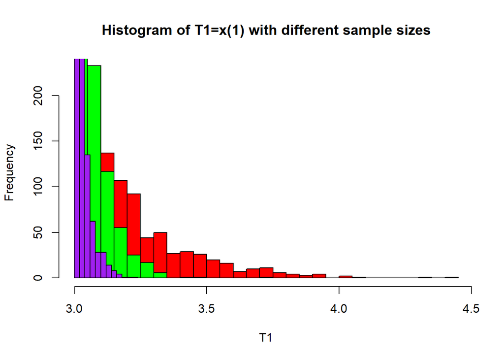

```r
n=c(5,15,30)
mu=3
sam_mean_T1=sam_var_T1=numeric(length(n))
sam_mean_T2=sam_var_T2=numeric(length(n))

T1_list=list()
T2_list=list()

for (i in 1:length(n)){
  x=matrix((rexp(1000*n[i],1)+mu),nrow = 1000,ncol = n[i])

  T1=apply(x,1,min)
  T2=(apply(x,1,mean)-1)

  sam_mean_T1[i]=mean(T1)
  sam_mean_T2[i]=mean(T2)

  sam_var_T1[i]=var(T1)
  sam_var_T2[i]=var(T2)

  T1_list[[i]]=T1
  T2_list[[i]]=T2
}

hist(T1_list[[1]],breaks="FD",col="red",main="Histogram of T1=x(1) with different sample sizes",xlab="T1")
hist(T1_list[[2]],col="green",add=T)
hist(T1_list[[3]],col="purple",add=T)
```

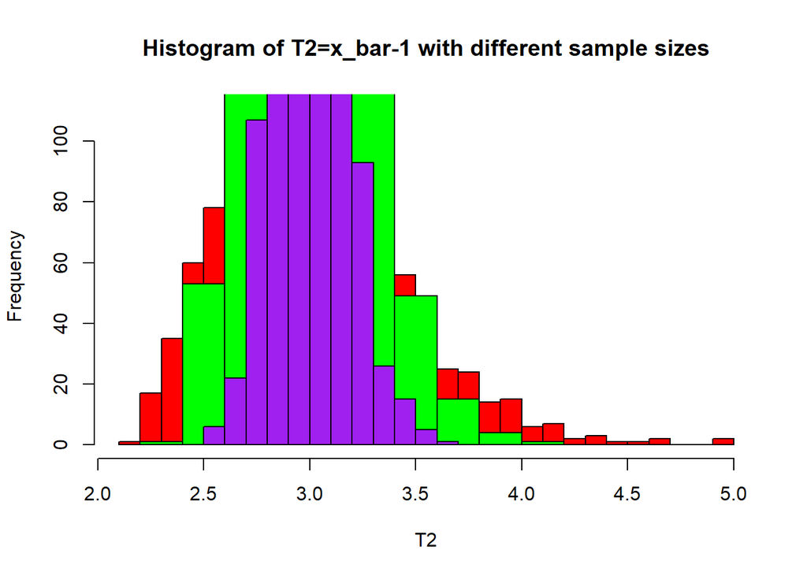

```r
hist(T2_list[[1]],breaks="FD",col="red",main="Histogram of T2=x_bar-1 with different sample sizes",xlab="T2")
hist(T2_list[[2]],col="green",add=T)
hist(T2_list[[3]],col="purple",add=T)
```

```r
cbind(n,sam_mean_T1,sam_var_T1)
```

```
##       n sam_mean_T1  sam_var_T1
## [1,]  5    3.195749 0.038803958
## [2,] 15    3.066317 0.004795407
## [3,] 30    3.032164 0.001065994
```

```r
cbind(n,sam_mean_T2,sam_var_T2)
```

```
##       n sam_mean_T2 sam_var_T2
## [1,]  5    3.006509 0.19709623
## [2,] 15    2.987856 0.06711903
## [3,] 30    2.999251 0.03203955
```

From this output, we conclude that as sample size increases variability in T1 and T2 decreases.

To conduct the simulation study from Exponential distribution with location parameter $\mu$ and scale parameter $\sigma$. Demonstrate the distribution and it’s descriptive statistics for different sample sizes of following statistic/estimators.

T1=$x_{(1)}$ & T2=$\bar{x}$-$x_{(1)}$

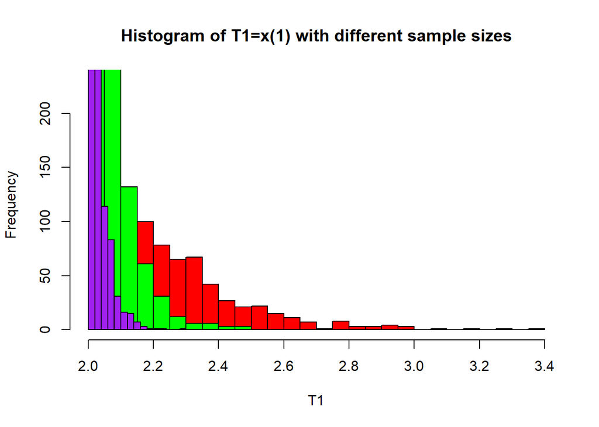

```r
n=c(5,15,30)
sam_mean_T1=sam_var_T1=numeric(length(n))
sam_mean_T2=sam_var_T2=numeric(length(n))
mu=2
sigma=1

T1_list=list()
T2_list=list()

for (i in 1:length(n)){
  y=matrix(runif(1000*n[i],0,1),nrow = 1000,ncol = n[i])
  x=mu-(sigma*log(1-y))

  T1=apply(x,1,min)
  x_bar=apply(x,1,mean)
  T2=x_bar-T1

  sam_mean_T1[i]=mean(T1)
  sam_mean_T2[i]=mean(T2)

  sam_var_T1[i]=var(T1)
  sam_var_T2[i]=var(T2)

  T1_list[[i]]=T1
  T2_list[[i]]=T2

}

hist(T1_list[[1]],breaks="FD",col="red",main="Histogram of T1=x(1) with different sample sizes",xlab="T1")
hist(T1_list[[2]],col="green",add=T)
hist(T1_list[[3]],col="purple",add=T)
```

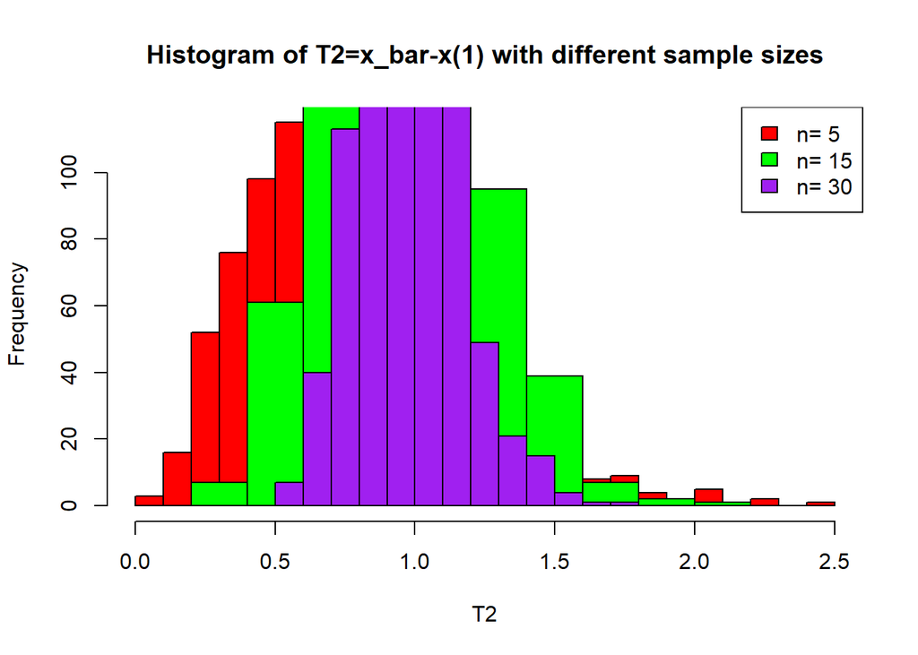

```r
hist(T2_list[[1]],breaks="FD",col="red",main="Histogram of T2=x_bar-x(1) with different sample sizes",xlab="T2")
hist(T2_list[[2]],col="green",add=T)
hist(T2_list[[3]],col="purple",add=T)

legend("topright",legend=paste("n=",n),
       fill=c("red","green","purple"))
```

```r
cbind(n,sam_mean_T1,sam_var_T1)
```

```
##       n sam_mean_T1  sam_var_T1
## [1,]  5    2.199768 0.037671459
## [2,] 15    2.072463 0.005323559
## [3,] 30    2.032067 0.001082945
```

```r
cbind(n,sam_mean_T2,sam_var_T2)
```

```
##       n sam_mean_T2 sam_var_T2
## [1,]  5   0.7907367 0.14521333
## [2,] 15   0.9345743 0.06466684
## [3,] 30   0.9678350 0.03071624
```

From this output, we conclude that as sample size increases variability in T1 and T2 decreases.